# IEOR 142 FINAL PROJECT

```r
data[data$suicides.100k.pop == min(data$suicides.100k.pop) & data$year > "2013" , ]
```

```
##                            country year    sex         age suicides_no
## 565            Antigua and Barbuda 2014 female 15-24 years           0
## 566            Antigua and Barbuda 2014 female 25-34 years           0
## 567            Antigua and Barbuda 2014 female 35-54 years           0
## 568            Antigua and Barbuda 2014 female  5-14 years           0
## 569            Antigua and Barbuda 2014 female 55-74 years           0
## 570            Antigua and Barbuda 2014 female   75+ years           0
## 571            Antigua and Barbuda 2014   male 15-24 years           0
## 572            Antigua and Barbuda 2014   male 25-34 years           0
## 573            Antigua and Barbuda 2014   male 35-54 years           0
## 574            Antigua and Barbuda 2014   male  5-14 years           0
## 575            Antigua and Barbuda 2014   male 55-74 years           0
## 576            Antigua and Barbuda 2014   male   75+ years           0
## 578            Antigua and Barbuda 2015 female 15-24 years           0
## 579            Antigua and Barbuda 2015 female 25-34 years           0
```

[output cut: 633 more lines]

The below visualization shows suicide is much more common in males than females in the US.

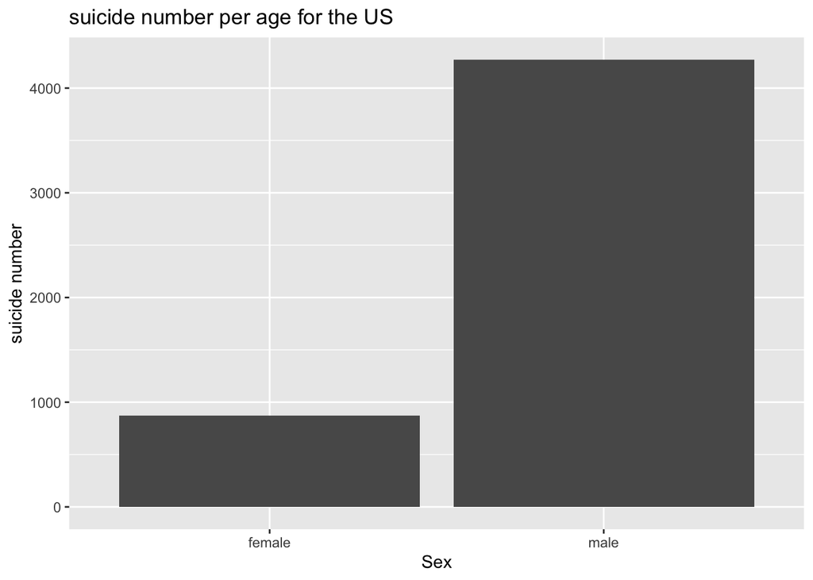

```r
us.data <- data.merged[data.merged$country == "United States",]

ggplot(us.data)  + ggtitle("suicide number per age for the US") +
geom_col(aes(x=us.data$sex, y=us.data$suicides.100k.pop)) + xlab("Sex") + ylab("suicide number")
```

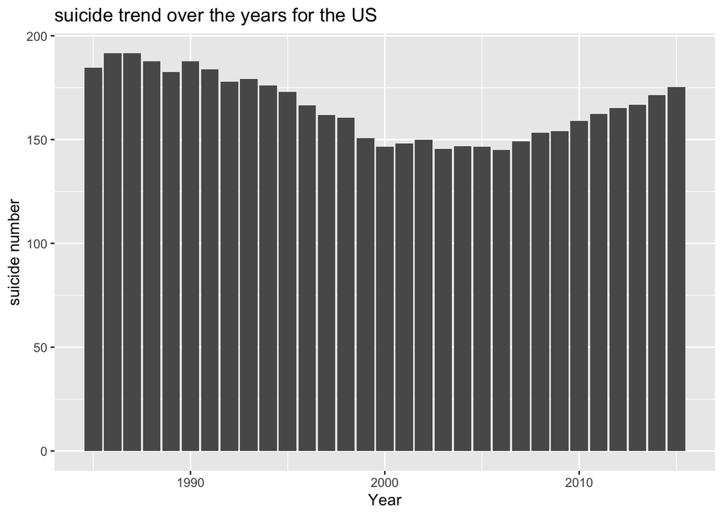

```r
ggplot(us.data)  + ggtitle("suicide trend over the years for the US") +
geom_col(aes(x=us.data$year, y=us.data$suicides.100k.pop)) + xlab("Year") + ylab("suicide number")
```

The generation with the highest suicide rate is Silent generation in the US.

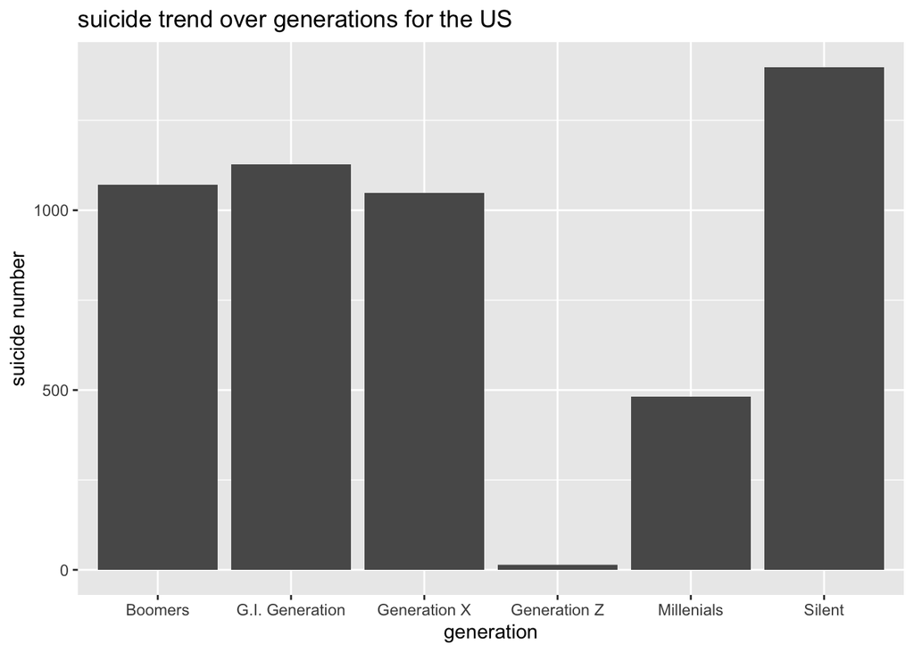

```r
ggplot(us.data)  + ggtitle("suicide trend over generations for the US") +
geom_col(aes(x= us.data$generation, y= us.data$suicides.100k.pop)) + xlab("generation") + ylab("suicide number")
```

```r
Japan.data <-  data.merged[data.merged$country == "Japan",]
```

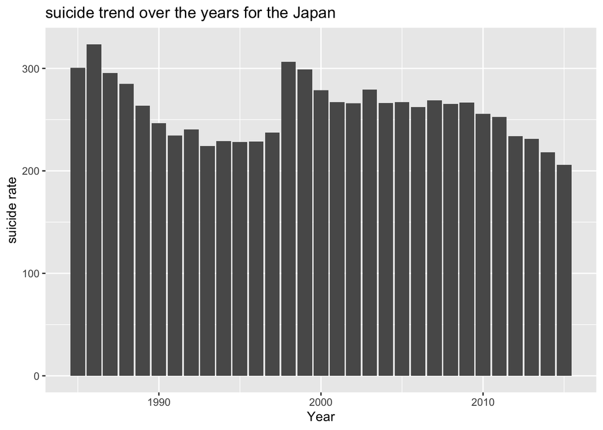

```r
ggplot(Japan.data)  + ggtitle("suicide trend over the years for the Japan") +
geom_col(aes(x= Japan.data$year, y= Japan.data$suicides.100k.pop)) + xlab("Year") + ylab("suicide rate")
```

Suicide among males is also more common in Japan than in females.

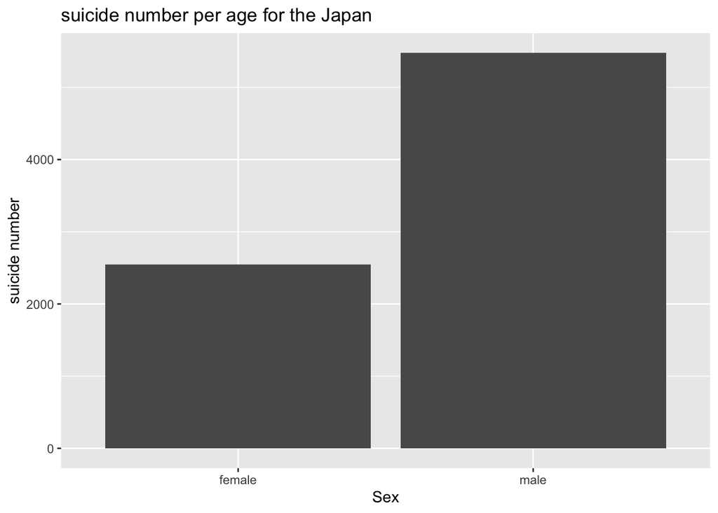

```r
ggplot(Japan.data)  + ggtitle("suicide number per age for the Japan") +
geom_col(aes(x=Japan.data$sex, y=Japan.data$suicides.100k.pop)) + xlab("Sex") + ylab("suicide number")
```

Similarly to the US, Japan’s suicide rate is highest among the Silent generation.

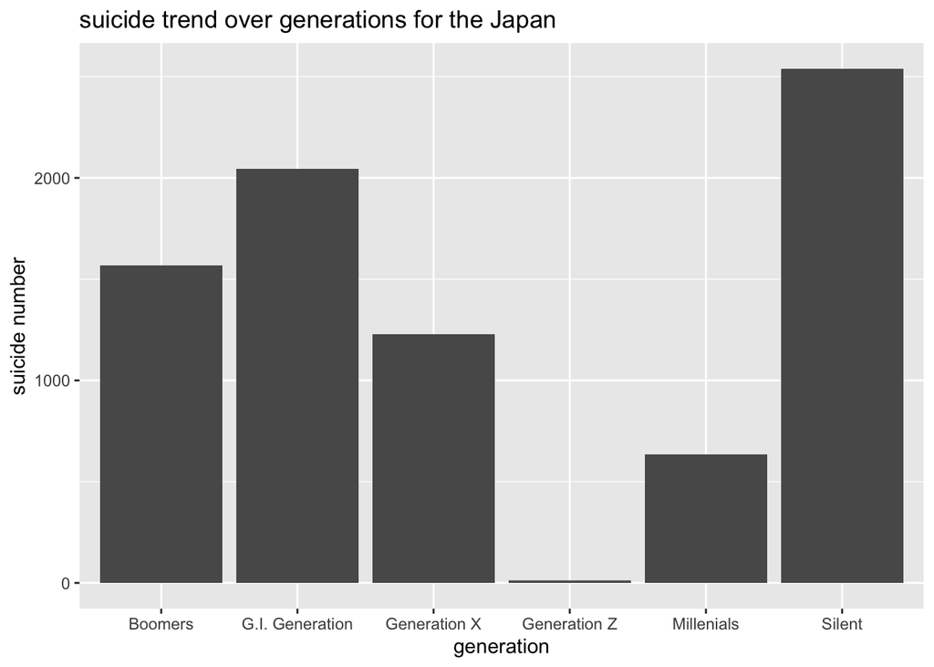

```r
ggplot(Japan.data)  + ggtitle("suicide trend over generations for the Japan") +
geom_col(aes(x= Japan.data$generation, y= Japan.data$suicides.100k.pop)) + xlab("generation") + ylab("suicide number")
```

Japan has a highest recorded suicide rate out of Japan and the US given the years, occuring in 1986.

```r
data.merged[data.merged$suicides.100k.pop == min(data.merged$suicides.100k.pop), ]
```

```
##     country year    sex        age suicides_no population
## 552   Japan 1991 female 5-14 years          14    7536000
##     suicides.100k.pop country.year HDI.for.year gdp_per_capita....
## 552              0.19    Japan1991        0.821              30688
##     generation gdp_for_year....
## 552 Millenials      3.58442e+12
```

```r
data.merged[data.merged$suicides.100k.pop == max(data.merged$suicides.100k.pop), ]
```

```
##     country year  sex       age suicides_no population suicides.100k.pop
## 493   Japan 1986 male 75+ years        1488    1889000             78.77
##     country.year HDI.for.year gdp_per_capita....      generation
## 493    Japan1986           NA              18288 G.I. Generation
##     gdp_for_year....
## 493     2.078953e+12
```

```r
#plot(data.merged[data.merged$suicides_no == max(data.merged$suicides_no), ])
```